# IODS course project

Jaakko Keinanen

# About the project

This seems like a great course, although I don??t know yet whether I will have immediate use for the skills I learn here but hopefully in the future this will be useful. I??m also sure that learning about R and open data will make me a better researcher.

http://www.github.com/jaakkoik/IODS-project

# 1. Description of the data

The dataset consists of students responses to a questionnaire about study habits and attitudes, including also exam points reflecting how succesful they were during a course. It consists of 8 variables, including the id-variable X, gender, age, and variables that describe the students attitude and learning styles, and exam points. The data has 166 different students answers in it.

```r
list.files("~/Documents/Jaakon tutkimus/Open data kurssi s2017/GitHub/IODS-project/data")
```

```
## [1] "create_alc.R"     "create_alc.csv"   "learning2014.csv"
## [4] "student-mat.csv"  "student-por.csv"
```

```r
students2014 <- read.csv("~/Documents/Jaakon tutkimus/Open data kurssi s2017/GitHub/IODS-project/data/learning2014.csv", header =TRUE, sep = ",")

dim(students2014)
```

```
## [1] 166   8
```

```r
str(students2014)
```

```
## 'data.frame':    166 obs. of  8 variables:
##  $ X       : int  1 2 3 4 5 6 7 8 9 10 ...
##  $ gender  : Factor w/ 2 levels "F","M": 1 2 1 2 2 1 2 1 2 1 ...
##  $ Age     : int  53 55 49 53 49 38 50 37 37 42 ...
##  $ Attitude: int  37 31 25 35 37 38 35 29 38 21 ...
##  $ deep    : num  3.58 2.92 3.5 3.5 3.67 ...
##  $ stra    : num  3.38 2.75 3.62 3.12 3.62 ...
##  $ surf    : num  2.58 3.17 2.25 2.25 2.83 ...
##  $ Points  : int  25 12 24 10 22 21 21 31 24 26 ...
```

# 2. Graphical overview of the data:

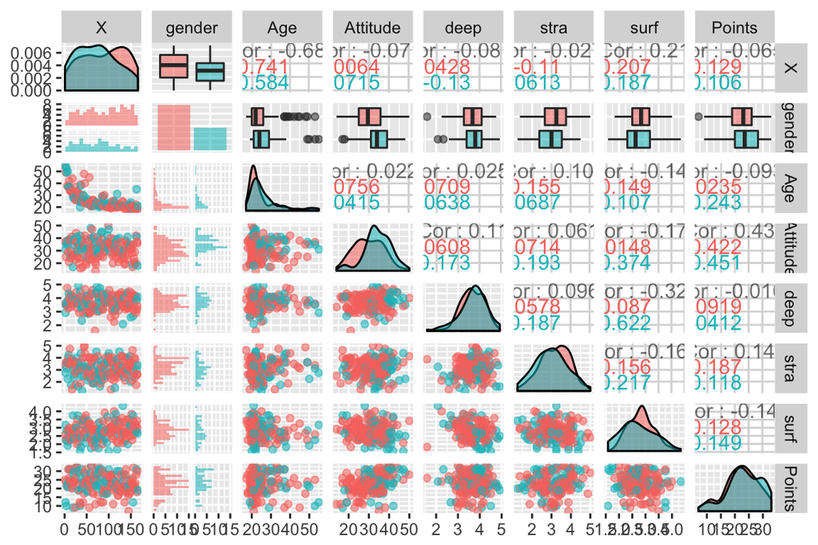

```r
library(ggplot2)
library(GGally)
p3 <- ggpairs(students2014, mapping = aes(col=gender, alpha=0.3), lower = list(combo = wrap("facethist", bins = 20)))
p3
```

From the graph we see that exam points correlates most strongly with attitude and the second largest correlation is with strategic learning -variable. From the distributions it is visible that there are some differences between sexes in the distributions, for example men tend to have more attitude points but the differences in most of the variables are not large.

# 3. The regression model:

Dependent variable: points. Independent variable: attitude, gender, stra.

```r
my_model <- lm(Points ~ Attitude + gender + stra, data = students2014)
summary(my_model)
```

```
##
## Call:
## lm(formula = Points ~ Attitude + gender + stra, data = students2014)
##
## Residuals:
##      Min       1Q   Median       3Q      Max
## -17.7179  -3.3285   0.5343   3.7412  10.9007
##
## Coefficients:
##             Estimate Std. Error t value Pr(>|t|)
## (Intercept)  8.97982    2.40303   3.737 0.000258 ***
## Attitude     0.35100    0.05956   5.893 2.13e-08 ***
## genderM     -0.22362    0.92477  -0.242 0.809231
## stra         0.89107    0.54409   1.638 0.103419
## ---
## Signif. codes:  0 '***' 0.001 '**' 0.01 '*' 0.05 '.' 0.1 ' ' 1
##
## Residual standard error: 5.304 on 162 degrees of freedom
## Multiple R-squared:  0.2051, Adjusted R-squared:  0.1904
## F-statistic: 13.93 on 3 and 162 DF,  p-value: 3.982e-08
```

From the summary of the model we see that only Attitude is significant (Pr < 0.05). Gender is the least significant (Pr largest). We run the model again after removing gender from it.

```r
my_model2 <- lm(Points ~ Attitude + stra, data = students2014)
summary(my_model2)
```

```
##
## Call:
## lm(formula = Points ~ Attitude + stra, data = students2014)
##
## Residuals:
##      Min       1Q   Median       3Q      Max
## -17.6436  -3.3113   0.5575   3.7928  10.9295
##
## Coefficients:
##             Estimate Std. Error t value Pr(>|t|)
## (Intercept)  8.97290    2.39591   3.745  0.00025 ***
## Attitude     0.34658    0.05652   6.132 6.31e-09 ***
## stra         0.91365    0.53447   1.709  0.08927 .
## ---
## Signif. codes:  0 '***' 0.001 '**' 0.01 '*' 0.05 '.' 0.1 ' ' 1
##
## Residual standard error: 5.289 on 163 degrees of freedom
## Multiple R-squared:  0.2048, Adjusted R-squared:  0.1951
## F-statistic: 20.99 on 2 and 163 DF,  p-value: 7.734e-09
```

After removing gender from the model stra is still not significant but the coefficient estimate is slightly larger.

4. From the summary of the last model (my_model2) we can interpret that when Attitude points increase by one the exam points increase by 0.35 (the coeffficient estimate is 0.35). When stra points increase by one the exam points increase by 0.91. The multiple R squared is 0.20 which shows that 20 % of the variability in the exam scores is explained by the attitude and stra variables.

# 5. Diagnostic plots.

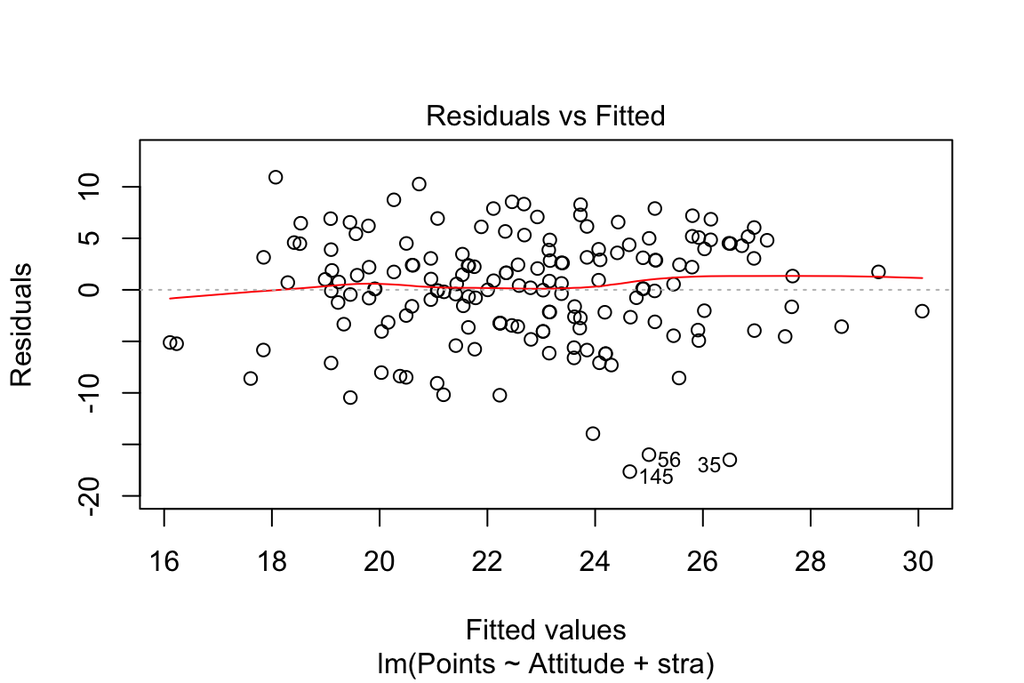

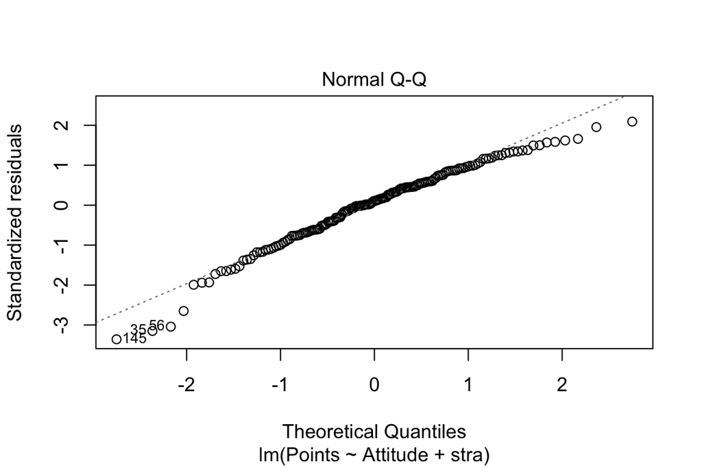

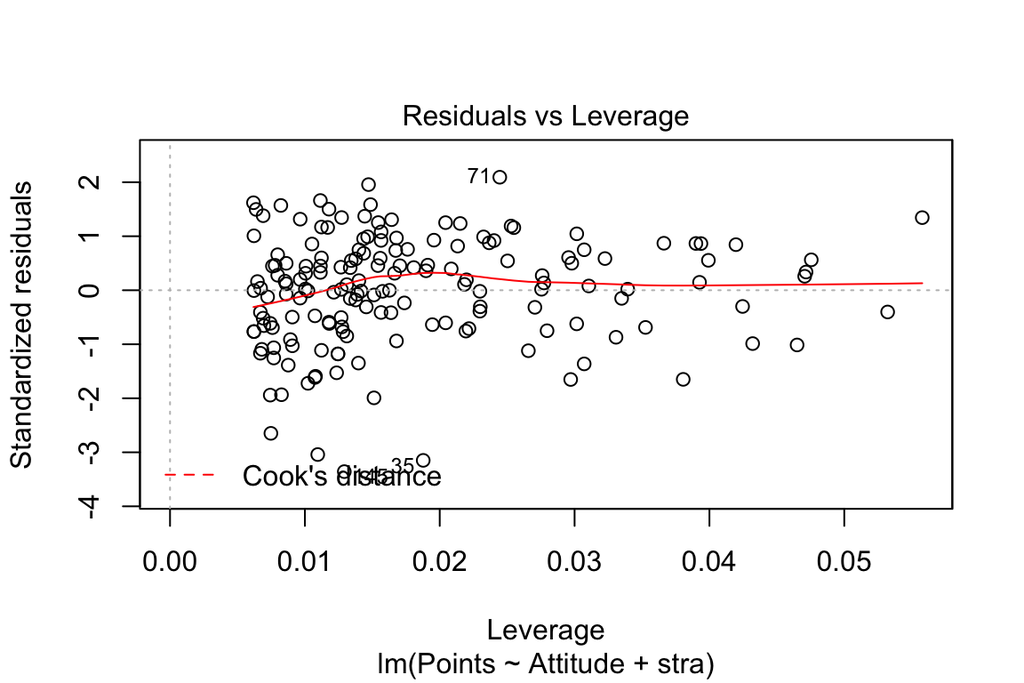

```r
plot(my_model2, which=c(1, 2, 5))
```

QQ-plot shows how the errors in the model are distributed. The errors should be normally distributed for the regression model to be reliable. From the plot it is visible that the circles fit on the line quite well although there is some deviation from the line in both ends. All in all, the errors seem to be normally distributed.

Residual vs fitted -plot shows how well the data meets the assumption that the size of the errors should not depend on the explanatory variables in the model. When the points are randomly spread on the plot, as they seem to be here, the assumption is usually met

Residuals vs leverage plot shows how big of an impact the outliers get. In the plot, circles in the upper right or lower left corners may be influential outliers. When circles are out of cooks distance the are influential to the regression model. Here all the cases are within cook??s distance so the assumption is met.

# Chapter 3. RStudio Exercise 3

Read data to “alc” and check the column names.

```r
alc <- read.csv("/Users/caroram/Documents/Jaakon tutkimus/Open data kurssi s2017/GitHub/IODS-project/data/create_alc.csv")
colnames(alc)
```

```
##  [1] "school"     "sex"        "age"        "address"    "famsize"
##  [6] "Pstatus"    "Medu"       "Fedu"       "Mjob"       "Fjob"
## [11] "reason"     "nursery"    "internet"   "guardian"   "traveltime"
## [16] "studytime"  "failures"   "schoolsup"  "famsup"     "paid"
## [21] "activities" "higher"     "romantic"   "famrel"     "freetime"
## [26] "goout"      "Dalc"       "Walc"       "health"     "absences"
## [31] "G1"         "G2"         "G3"         "alc_use"    "high_use"
```

```r
str(alc)
```

```
## 'data.frame':    382 obs. of  35 variables:
##  $ school    : Factor w/ 2 levels "GP","MS": 1 1 1 1 1 1 1 1 1 1 ...
##  $ sex       : Factor w/ 2 levels "F","M": 1 1 1 1 1 2 2 1 2 2 ...
##  $ age       : int  18 17 15 15 16 16 16 17 15 15 ...
##  $ address   : Factor w/ 2 levels "R","U": 2 2 2 2 2 2 2 2 2 2 ...
##  $ famsize   : Factor w/ 2 levels "GT3","LE3": 1 1 2 1 1 2 2 1 2 1 ...
##  $ Pstatus   : Factor w/ 2 levels "A","T": 1 2 2 2 2 2 2 1 1 2 ...
##  $ Medu      : int  4 1 1 4 3 4 2 4 3 3 ...
##  $ Fedu      : int  4 1 1 2 3 3 2 4 2 4 ...
##  $ Mjob      : Factor w/ 5 levels "at_home","health",..: 1 1 1 2 3 4 3 3 4 3 ...
##  $ Fjob      : Factor w/ 5 levels "at_home","health",..: 5 3 3 4 3 3 3 5 3 3 ...
##  $ reason    : Factor w/ 4 levels "course","home",..: 1 1 3 2 2 4 2 2 2 2 ...
##  $ nursery   : Factor w/ 2 levels "no","yes": 2 1 2 2 2 2 2 2 2 2 ...
##  $ internet  : Factor w/ 2 levels "no","yes": 1 2 2 2 1 2 2 1 2 2 ...
##  $ guardian  : Factor w/ 3 levels "father","mother",..: 2 1 2 2 1 2 2 2 2 2 ...
```

[output cut: 21 more lines]

Four variables that could be associated with alcohol use and hypotheses: 1) sex: boys might drink more alcohol tha girls 2) age: those who are old enough might drink more 3) studytime: those who study more might dring less 4) famrel: those with good family relationships might drink more Check distributions and correlations.

```r
library(dplyr)
```

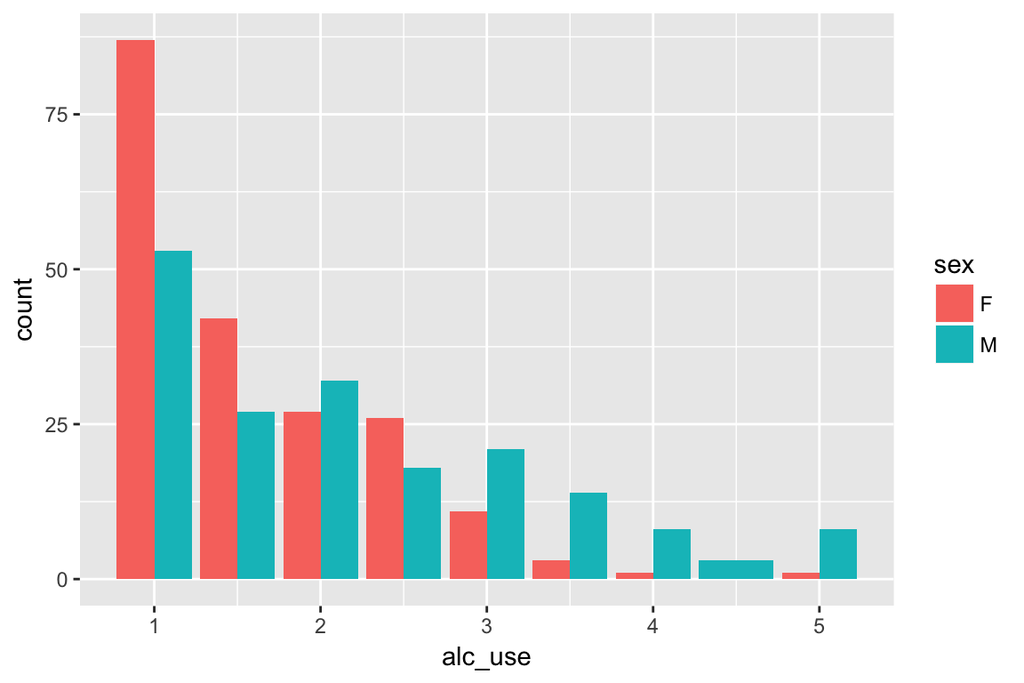

```r
library(ggplot2)
library(tidyr)
g1 <- ggplot(data = alc, aes(x = alc_use)) + geom_bar(aes(fill=sex), position="dodge")
g1
```

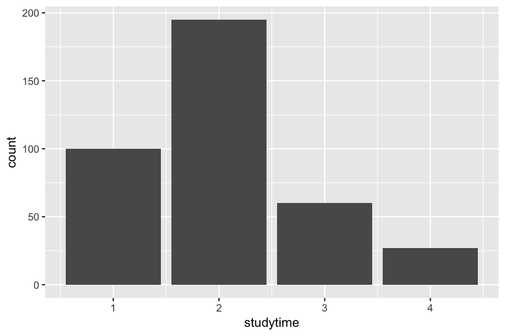

```r
g2 <- ggplot(data = alc, aes(x = studytime)) + geom_bar()
g2
```

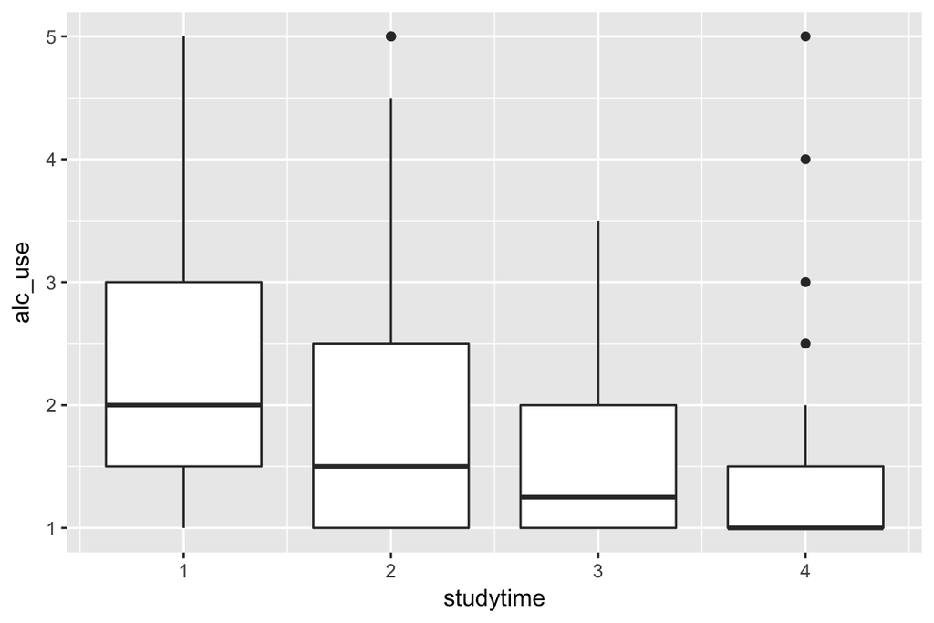

```r
g3 <- ggplot(alc, aes(studytime, alc_use)) + geom_boxplot(aes(group=studytime))
g3
```

#logistic regression to predict alcohol high use with preselected 4 variables:

First change the studytime and famrel variables as factors (categorical).

```r
alc$studytime <- factor(alc$studytime)
alc$famrel <- factor(alc$famrel)
m <- glm(high_use ~ age + studytime + sex + famrel, data = alc, family = "binomial")
summary(m)
```

```
##
## Call:
## glm(formula = high_use ~ age + studytime + sex + famrel, family = "binomial",
##     data = alc)
##
## Deviance Residuals:
##     Min       1Q   Median       3Q      Max
## -1.4630  -0.8367  -0.6373   1.1158   2.2807
##
## Coefficients:
##             Estimate Std. Error z value Pr(>|z|)
## (Intercept) -4.92781    1.90605  -2.585  0.00973 **
## age          0.23811    0.10162   2.343  0.01912 *
## studytime2  -0.26540    0.27519  -0.964  0.33484
## studytime3  -1.18329    0.45610  -2.594  0.00948 **
## studytime4  -1.11392    0.59560  -1.870  0.06145 .
## sexM         0.73609    0.25197   2.921  0.00348 **
## famrel2      0.75910    0.97477   0.779  0.43613
## famrel3      0.55588    0.89199   0.623  0.53316
## famrel4      0.01567    0.86874   0.018  0.98561
## famrel5     -0.29474    0.88756  -0.332  0.73983
## ---
## Signif. codes:  0 '***' 0.001 '**' 0.01 '*' 0.05 '.' 0.1 ' ' 1
##
## (Dispersion parameter for binomial family taken to be 1)
##
##     Null deviance: 465.68  on 381  degrees of freedom
## Residual deviance: 426.33  on 372  degrees of freedom
## AIC: 446.33
##
## Number of Fisher Scoring iterations: 4
```

Interpretation: Age is a significant predictor of high use (p<0.05). So is studytime category 3 (compared to category 1 which is not shown). This meand studying 5-10 hours weekly is associated with less high use than studying <2 hours. Category 4 (studying more than 10 hours weekly) was not significantly associated with high use. Male sex increased the probability of high use significantly. Family relations are not associated with high use. #Odds ratios and confidence intervals:

```r
OR <- coef(m) %>% exp
CI<- confint(m) %>% exp
cbind(OR, CI)
```

```
##                      OR        2.5 %     97.5 %
## (Intercept) 0.007242324 0.0001543051  0.2828385
## age         1.268854575 1.0416646124  1.5534993
## studytime2  0.766901440 0.4478608817  1.3200182
## studytime3  0.306269593 0.1186265549  0.7220426
## studytime4  0.328270171 0.0888754833  0.9696930
## sexM        2.087754319 1.2785290293  3.4399886
## famrel2     2.136357015 0.3477827163 18.2954416
## famrel3     1.743477847 0.3408184256 13.2361471
## famrel4     1.015793214 0.2089632663  7.4639818
## famrel5     0.744723795 0.1466521034  5.6113052
```

CI:s of predictors do not include 0.

```r
# predict() the probability of high_use
probabilities <- predict(m, type = "response")

# add the predicted probabilities to 'alc'
alc <- mutate(alc, probability = probabilities)

# use the probabilities to make a prediction of high_use
alc <- mutate(alc, prediction = probability>0.5)

# see the last ten original classes, predicted probabilities, and class predictions
select(alc, studytime, famrel, sex, high_use, probability, prediction) %>% tail(10)
```

```
##     studytime famrel sex high_use probability prediction
## 373         1      4   M    FALSE   0.5861623       TRUE
## 374         1      5   M     TRUE   0.4500661      FALSE
## 375         3      5   F    FALSE   0.1071889      FALSE
## 376         1      4   F    FALSE   0.3483997      FALSE
## 377         3      5   F    FALSE   0.1321975      FALSE
## 378         2      4   F    FALSE   0.2908050      FALSE
## 379         2      2   F    FALSE   0.4630561      FALSE
## 380         2      1   F    FALSE   0.2875839      FALSE
## 381         1      2   M     TRUE   0.6491547       TRUE
## 382         1      4   M     TRUE   0.5274744       TRUE
```

```r
# tabulate the target variable versus the predictions
table(high_use = alc$high_use, prediction = alc$prediction)
```

```
##         prediction
## high_use FALSE TRUE
##    FALSE   251   17
##    TRUE     89   25
```

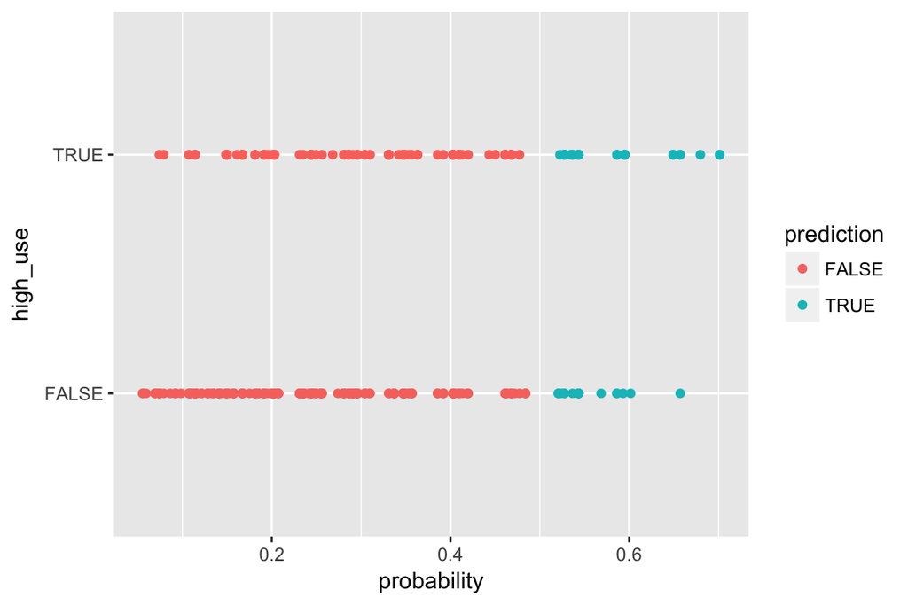

```r
# initialize a plot of 'high_use' versus 'probability' in 'alc'
g <- ggplot(alc, aes(x = probability, y = high_use, col=prediction))

# define the geom as points and draw the plot
g + geom_point()
```

```r
# tabulate the target variable versus the predictions
table(high_use = alc$high_use, prediction = alc$prediction) %>% prop.table %>% addmargins()
```

```
##         prediction
## high_use      FALSE       TRUE        Sum
##    FALSE 0.65706806 0.04450262 0.70157068
##    TRUE  0.23298429 0.06544503 0.29842932
##    Sum   0.89005236 0.10994764 1.00000000
```

```r
# define a loss function (mean prediction error)
loss_func <- function(class, prob) {
  n_wrong <- abs(class - prob) > 0.5
  mean(n_wrong)
}

# call loss_func to compute the average number of wrong predictions in the (training) data
loss_func(class = alc$high_use, prob = alc$probability)
```

```
## [1] 0.2774869
```